# Intro

18090

2019年1月10日

## Question

Write a .Rmd file to implement at least three examples of different types in the above books (texts, numerical results, tables, and figures).

## Answer

example 1:

```r
set.seed(123)
x<-rnorm(100)
x
```

```
##   [1] -0.560475647 -0.230177489  1.558708314  0.070508391  0.129287735
##   [6]  1.715064987  0.460916206 -1.265061235 -0.686852852 -0.445661970
##  [11]  1.224081797  0.359813827  0.400771451  0.110682716 -0.555841135
##  [16]  1.786913137  0.497850478 -1.966617157  0.701355902 -0.472791408
##  [21] -1.067823706 -0.217974915 -1.026004448 -0.728891229 -0.625039268
##  [26] -1.686693311  0.837787044  0.153373118 -1.138136937  1.253814921
##  [31]  0.426464221 -0.295071483  0.895125661  0.878133488  0.821581082
##  [36]  0.688640254  0.553917654 -0.061911711 -0.305962664 -0.380471001
##  [41] -0.694706979 -0.207917278 -1.265396352  2.168955965  1.207961998
##  [46] -1.123108583 -0.402884835 -0.466655354  0.779965118 -0.083369066
##  [51]  0.253318514 -0.028546755 -0.042870457  1.368602284 -0.225770986
##  [56]  1.516470604 -1.548752804  0.584613750  0.123854244  0.215941569
##  [61]  0.379639483 -0.502323453 -0.333207384 -1.018575383 -1.071791226
##  [66]  0.303528641  0.448209779  0.053004227  0.922267468  2.050084686
##  [71] -0.491031166 -2.309168876  1.005738524 -0.709200763 -0.688008616
##  [76]  1.025571370 -0.284773007 -1.220717712  0.181303480 -0.138891362
##  [81]  0.005764186  0.385280401 -0.370660032  0.644376549 -0.220486562
##  [86]  0.331781964  1.096839013  0.435181491 -0.325931586  1.148807618
##  [91]  0.993503856  0.548396960  0.238731735 -0.627906076  1.360652449
##  [96] -0.600259587  2.187332993  1.532610626 -0.235700359 -1.026420900
```

example 2:

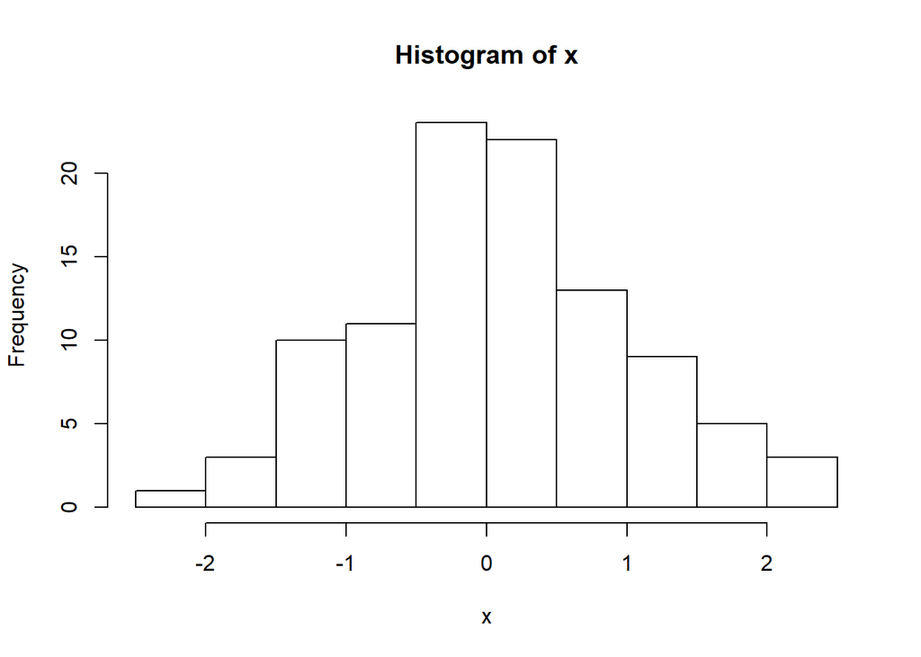

```r
hist(x,breaks = 10)
```

example 3:

```r
x<-runif(10,0,100)
y<-runif(10,0,100)
xy<-data.frame(num=1:10,score1=round(x),score2=round(y))
knitr::kable(xy, format = "markdown")
```

| num | score1 | score2 |
| --- | --- | --- |
| 1 | 24 | 48 |
| 2 | 96 | 25 |
| 3 | 60 | 22 |
| 4 | 52 | 67 |
| 5 | 40 | 5 |
| 6 | 88 | 70 |
| 7 | 36 | 35 |
| 8 | 29 | 41 |
| 9 | 17 | 82 |
| 10 | 17 | 92 |

## Question

Exercises 5.4 (Page 150,Statistical Computing with R )

Write a function to compute a Monte Carlo estimate of the Beta(3, 3) cdf, and use the function to estimate F(x) for x = 0.1, 0.2,…, 0.9. Compare the estimates with the values returned by the pbeta function in R.

## Answer

$X \sim Beta(3,3)$.So the pdf is
$$f(x)=\frac{\Gamma(3+3)}{\Gamma(3)\Gamma(3)}x^2(1-x)^2=30x^2(1-x)^2.$$
And its cdf is
$$F(x) =\int_0^xf(t)dt =\int_0^x30 t^2(1-t)^2dt=E_Y(30xy^2(1-y)^2),Y \sim U(0,x)$$

So F(x) can be estimated with
$$\hat F(x)=\frac{1}{m} \sum_{i=1}^mg(y_i) .$$

Where
$$g(y)=30xy^2(1-y)^2,Y \sim U(0,x).$$

Then geting the R code,and the estimate value of F(x) for x = 0.1, 0.2,…, 0.9:

````
```r
MCbeta<-function(x,m=10000){
    y <- runif(m, min=0, max=x)
    F.hat <- mean(30*x*y^2*(1-y)^2)      #MC method
}              #function for computing estimate of Beta(3,3)
for (i in 1:9/10) print(MCbeta(i))           #print F(0.1),F(0.2)????F(0.9)
```

```
## [1] 0.008475323
## [1] 0.05725933
## [1] 0.1634159
## [1] 0.3120066
## [1] 0.4997212
## [1] 0.6833414
## [1] 0.8347775
## [1] 0.9413268
## [1] 0.999729
```
````

The above is the estimate value of F(x) for x = 0.1, 0.2,…, 0.9,and we can compare the estimates with the values returned by the pbeta function:

````
```r
c<-matrix(0,nrow=9,ncol=3)
for (i in 1:9) c[i,]<-c(MCbeta(i/10),pbeta(i/10,3,3),MCbeta(i/10)/pbeta(i/10,3,3))
colnames(c)=c('F_hat','F','F_hat/F')
knitr::kable(t(round(c,6)),col.names=c(  '0.1', '0.2', '0.3', '0.4', '0.5', '0.6', '0.7', '0.8','0.9'),format='markdown')       #compare with the pbeta function
```



|        |      0.1|      0.2|      0.3|      0.4|      0.5|      0.6|      0.7|      0.8|      0.9|
|:-------|--------:|--------:|--------:|--------:|--------:|--------:|--------:|--------:|--------:|
|F_hat   | 0.008650| 0.058511| 0.164570| 0.317429| 0.499275| 0.677107| 0.841907| 0.945288| 0.981117|
|F       | 0.008560| 0.057920| 0.163080| 0.317440| 0.500000| 0.682560| 0.836920| 0.942080| 0.991440|
|F_hat/F | 1.000128| 0.995344| 1.004094| 1.003078| 0.996776| 1.003602| 1.008066| 1.000274| 0.991116|
````

## Question

Exercises 5.9 (Page 150,Statistical Computing with R )

The Rayleigh density [156, (18.76)] is
$$f(x)=\frac{x}{\sigma^2}e^{-x^2/(2\sigma^2)} ,x \geq 0,\sigma \geq0.$$
Implement a function to generate samples from a Rayleigh(??) distribution, using antithetic variables. What is the percent reduction in variance of $\frac{X+X'}{2}$ compared with $\frac{X_1+X_2}{2}$ for independent $X_1,X_2$?

## Answer

We can get the cdf of Rayleigh(??) distribution:
$$F(x)=\int_0^x f(t)dt=\int_0^x\frac{t}{\sigma^2}e^{-t^2/(2\sigma^2)}dt=\int_0^1\frac{x^2u}{\sigma^2}e^{-x^2u^2/(2\sigma^2)}du=E_u(\frac{x^2u}{\sigma^2}e^{-x^2u^2/(2\sigma^2)}),u\sim U(0,1)$$
So using antithetic variables,F(x) can be estimated with
$$\hat F(x)=\frac{1}{m} \sum_{i=1}^{m/2}\frac{g_x(u_i)+g_x(1-u_i)}{2} .$$
Where
$$g_x(u)=\frac{x^2u}{\sigma^2}e^{-x^2u^2/(2\sigma)^2},u \sim U(0,x).$$
So we get the R code:

````
```r
MCRAY <- function(x, R = 10000, sigma= 1,antithetic = TRUE) {
u <- runif(R/2)
if (!antithetic) v <- runif(R/2) else
v <- 1 - u  #using antithetic variables or not
u <- c(u, v)
cdf <- numeric(length(x))
for (i in 1:length(x)) {
g <- x[i]^2 *u/ sigma^2 * exp(-(u * x[i])^2 / (2*sigma^2))
cdf[i] <- mean(g)      #MC method
}
cdf
}
```
````

Then we compare the variance of $\frac{X+X'}{2}$ and $\frac{X_1+X_2}{2}$ for independent $X_1,X_2$.In other word,to compare using the antithetic variables or not.Using $sigma=1$. And in fact,we can know that
$$F(x)=\int_0^x f(t)dt=\int_0^x\frac{t}{\sigma^2}e^{-t^2/(2\sigma)^2}dt=-e^{-s}|_0^{x^2/(2\sigma^2)}=1-e^{-x^2/(2\sigma^2)}.$$
So we can also compare with this theoretical value. The R code and the results:

````
```r
###comparing the results
x <- c(1:5/2)
sigma<-1
ray <- 1-exp(-x^2/2/sigma^2)  #theoretical value
set.seed(123)  #set random seed
mc1 <- MCRAY(x, antithetic = FALSE)  #no antithetic variables,one time
set.seed(123)
mc2 <- MCRAY(x) #using antithetic variables,one time
print(round(rbind(x, mc1, mc2, ray),5))
```

```
##        [,1]    [,2]    [,3]    [,4]    [,5]
## x   0.50000 1.00000 1.50000 2.00000 2.50000
## mc1 0.11701 0.39260 0.67584 0.86808 0.96232
## mc2 0.11751 0.39361 0.67585 0.86566 0.95743
## ray 0.11750 0.39347 0.67535 0.86466 0.95606
```

```r
###comparing the variance
m <- 1000
MC1 <- MC2 <- numeric(m)
x<-1
for (i in 1:m) {
MC1[i] <- MCRAY(x, R = 1000, anti = FALSE)   #no antithetic variables,1000 time
MC2[i] <- MCRAY(x, R = 1000)              #using antithetic variables,1000 time
}
SDMC1<-sd(MC1)
SDMC2<-sd(MC2)
VARpro<-(var(MC1)-var(MC2))/var(MC1)  #lost proportion by using antithetic variables
print(round(rbind(SDMC1,SDMC2,VARpro), 3))
```

```
##         [,1]
## SDMC1  0.006
## SDMC2  0.002
## VARpro 0.909
```
````

We can see that the antithetic variables effectively reduces the variance.

## Question

Exercises 5.13 & 5.14 (Page 151,Statistical Computing with R )

Find two importance functions $f_1$ and $f_2$ that are supported on $(1, ??)$ and are ??close?? to
$$g(x)=\frac{x^2}{\sqrt{2\pi}}e^{-\frac{x^2}{2}},x>1$$
Which of your two importance functions should produce the smaller variance in estimating
$$\int_1^\infty\frac{x^2}{\sqrt{2\pi}}e^{-\frac{x^2}{2}} dx$$
by importance sampling? Explain.

Obtain a Monte Carlo estimate of
$$\int_1^\infty\frac{x^2}{\sqrt{2\pi}}e^{-\frac{x^2}{2}} dx$$
by importance sampling.

## Answer

I read the textbook and the notes carefully,and I think the importance function is not necessary to be 0 in $x\leq 1$.

So,first,we think of the standard normal distribution:
$$Y_1\sim N(0,1)$$
The pdf is:
$$f_1(y)=\sqrt{\frac{1}{2\pi}}e^{-\frac{y^2}{2}}$$
And then we think of a transformation of the normal distribution:
$$Y_2=\left| X \right|+1 ,X \sim N(0,1)$$
Then we have the pdf of Y:
$$f_2(y)=\sqrt{\frac{2}{\pi}}e^{-\frac{(y-1)^2}{2}},y>1$$
The similarity is important.I think although the first one is more similar to g(x),but another problem that cannot be ignored is,if we use the first one,many samples become invalid.Because when $y\leq1$,$g(x)=0$,this sample is useless.

So I think the second function is better than the first one.Then we can check. We can get:
$$\theta=\int g(x)dx=\int_1^\infty \frac{g(x)}{f_1(x)}f_1(x)dx=E(g(X)/f_1(X))=E(x^2I_{(x>1)}),x\sim N(0,1)$$
$$\theta=\int g(x)dx=\int \frac{g(x)}{f_2(x)}f_2(x)dx=E(g(X)/f_2(X))=E(\frac{x^2}{2}e^{-(2x-1)/2}),x=\left| y \right|+1,y\sim N(0,1)$$
The R code is:

````
```r
m <- 10000
theta.hat <- se <- numeric(2)

x <- rnorm(m)  #using f1
fg <- x^2 * (x > 1)
theta.hat[1] <- mean(fg)
se[1] <- sd(fg)

y <- rnorm(m)  #using f2
x=abs(y)+1
fg <- x^2/2*exp(-x+0.5)
theta.hat[2] <- mean(fg)
se[2] <- sd(fg)

rbind(theta.hat, se)
```

```
##                [,1]      [,2]
## theta.hat 0.3972768 0.4006339
## se        1.1617393 0.0437870
```
````

This is the Monte Carlo estimate of
$$\int_1^\infty\frac{x^2}{\sqrt{2\pi}}e^{-\frac{x^2}{2}} dx$$

And the result confirmed my conjecture,that function 2 is better than function 1.It has the less standard deviation.

## Question

Exercises 6.9 (Page 181,Statistical Computing with R )

Let $X$ be a non-negative random variable with $\mu = E[X] < \infty$. For a random sample $x_1, . . . , x_n$ from the distribution of $X$, the Gini ratio is defined by
$$G = \frac{1}{2n^2\mu}\sum_{j=1}^n\sum_{i=1}^n \left|x_i-x_j \right|.$$
The Gini ratio is applied in economics to measure inequality in income distribution (see e.g. [163]). Note that G can be written in terms of the order statistics $x_{(i)}$ as
$$G = \frac{1}{n^2 \mu}\sum_{i=1}^n(2i-n-1)x_{(i)}.$$
If the mean is unknown, let $\hat{G}$ be the statistic $G$ with $\mu$ replaced by $\bar{x}$. Estimate by simulation the mean, median and deciles of $\hat{G}$ if $X$ is standard lognormal. Repeat the procedure for the uniform distribution and Bernoulli(0.1). Also construct density histograms of the replicates in each case.

## Answer

According the problem, what we’re going to do is sampling from the standard lognormal(or uniform distribution or Bernoulli(0.1)) and repeating.Then we estimate the mean, median and deciles of $\hat{G}$.

$$\hat{G} = \frac{1}{n^2 \bar{x}}\sum_{i=1}^n(2i-n-1)x_{(i)}.$$

We can suppose n=100.

So the R code is:

```r
m <- 1e3; n <- 100
g.hat <- numeric(m)
for(i in 1:m){
  x <- rlnorm(n) #standard lognormal
  x.bar<-mean(x)
  x1<-sort(x)
  beta<-c(((1-n)/2):((n-1)/2))*2
  g.hat[i]<- sum(x1*beta)/n^2/x.bar #calculate g.hat
}
c<- c(mean(g.hat),median(g.hat))
names(c)= c("mean.g","median.g")
print(c(c,quantile(g.hat,probs=seq(0,1,0.1))),4) #mean, median and deciles
```

```
##   mean.g median.g       0%      10%      20%      30%      40%      50%
##   0.5120   0.5102   0.3916   0.4616   0.4783   0.4894   0.4998   0.5102
##      60%      70%      80%      90%     100%
##   0.5196   0.5309   0.5447   0.5644   0.6668
```

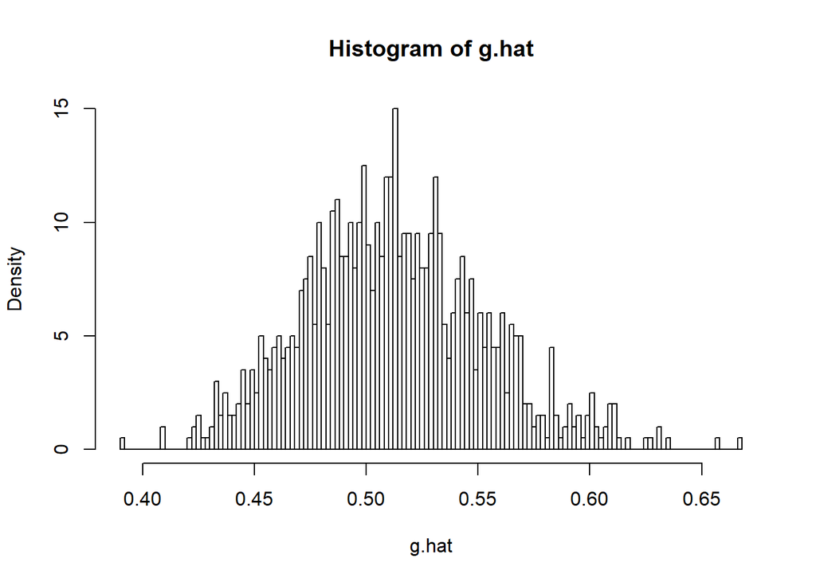

```r
hist(g.hat, prob=T,breaks=100) #density histogram
```

Similarly,we do this for uniform distribution and Bernoulli(0.1):

```r
m <- 1e3; n <- 100
g.hat <- numeric(m)
for(i in 1:m){
  x <- runif(n) #uniform(0,1)
  x.bar<-mean(x)
  x1<-sort(x)
  beta<-c(((1-n)/2):((n-1)/2))*2
  g.hat[i]<- sum(x1*beta)/n^2/x.bar #calculate g.hat
}
c<- c(mean(g.hat),median(g.hat))
names(c)= c("mean.g","median.g")
print(c(c,quantile(g.hat,probs=seq(0,1,0.1))),4) #mean, median and deciles
```

```
##   mean.g median.g       0%      10%      20%      30%      40%      50%
##   0.3292   0.3294   0.2604   0.2976   0.3077   0.3158   0.3233   0.3294
##      60%      70%      80%      90%     100%
##   0.3358   0.3422   0.3497   0.3603   0.4094
```

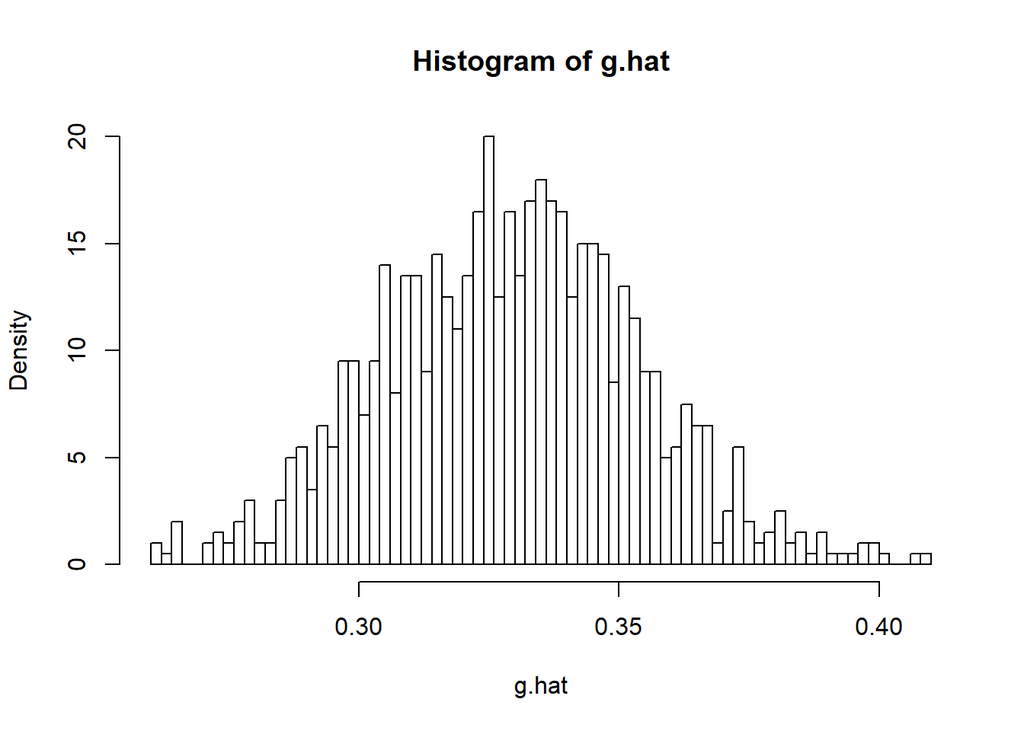

```r
hist(g.hat, prob=T,breaks=100) #density histogram
```

```r
##############################
m <- 1e3; n <- 100
g.hat <- numeric(m)
for(i in 1:m){
  x<-rbinom(n,1,0.1) #Bernoulli(0.1)
  x.bar<-mean(x)
  x1<-sort(x)
  beta<-c(((1-n)/2):((n-1)/2))*2
  g.hat[i]<- sum(x1*beta)/n^2/x.bar #calculate g.hat
}
c<- c(mean(g.hat),median(g.hat))
names(c)= c("mean.g","median.g")
print(c(c,quantile(g.hat,probs=seq(0,1,0.1))),4) #mean, median and deciles
```

```
##   mean.g median.g       0%      10%      20%      30%      40%      50%
##   0.8996   0.9000   0.7800   0.8600   0.8700   0.8800   0.8900   0.9000
##      60%      70%      80%      90%     100%
##   0.9100   0.9200   0.9300   0.9400   0.9800
```

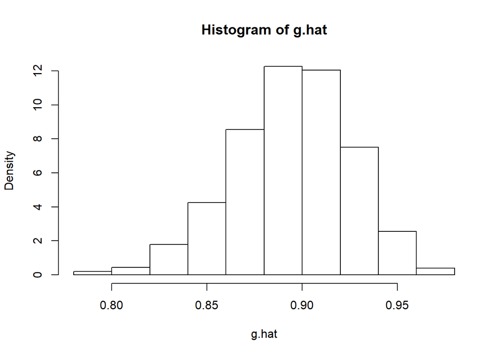

```r
hist(g.hat, prob=T,breaks=10) #density histogram
```

we can see that uniform distribution has smaller $\hat{G}$,followed by standard lognormal distribution,and finally the Bernoulli(0,1).

## Question

Exercises 6.10 (Page 181,Statistical Computing with R )

Construct an approximate 95% confidence interval for the Gini ratio $\gamma = E[G]$ if $X$ is lognormal with unknown parameters. Assess the coverage rate of the estimation procedure with a Monte Carlo experiment.

## Answer

We found that if $X$ is lognormal,Gini ratio is tend to be: $G=erf(\sigma /2)$

So we just need to construct an approximate 95% confidence interval for X’s parameters.

We suppose that n=10000,$\alpha=0.05$and $X$ is standard lognormal.

```r
alpha<-0.05
n<-10000
x<-rlnorm(n)
lx<-log(x)
ci1=(n-1)*var(lx)/qchisq(1-alpha/2,n-1)
ci2=(n-1)*var(lx)/qchisq(alpha/2,n-1)
CI1=pnorm(ci1,sd=sqrt(2))*2-1
CI2=pnorm(ci2,sd=sqrt(2))*2-1
print(c(CI1,CI2))
```

```
## [1] 0.4930492 0.5169608
```

Then we will test this CI.We suppose that n=10000,m=1000.

```r
n<-10000;m<-1000
g.hat <- numeric(m)
for(i in 1:m){
  x <- rlnorm(n) #standard lognormal
  x.bar<-mean(x)
  x1<-sort(x)
  beta<-c(((1-n)/2):((n-1)/2))*2
  g.hat[i]<- sum(x1*beta)/n^2/x.bar #calculate g.hat
}
print(c(sum(g.hat<=CI2&CI1<=g.hat)/m))#coverage rate
```

```
## [1] 0.207
```

## Question

Projects 6.B (Page 181,Statistical Computing with R )

Tests for association based on Pearson product moment correlation $\rho$, Spearman??s rank correlation coefficient $\rho_s$, or Kendall??s coefficient $\tau$, are implemented in cor.test. Show (empirically) that the nonparametric tests based on $\rho_s$ or $\tau$ are less powerful than the correlation test when the sampled distribution is bivariate normal. Find an example of an alternative (a bivariate distribution (X, Y ) such that X and Y are dependent) such that at least one of the nonparametric tests have better empirical power than the correlation test against this alternative.

## Answer

We suppose that $\rho=0.2,n=100,m=1000,\alpha=0.05$and $X$ is bivariate normal.

```r
library(MASS)
alpha <- .05
n <- 100
m <- 1000
rho <- .2
Sigma <- matrix(c(1,rho,rho,1),2,2)
test1 <- test2 <- test3 <- numeric(m)
# estimate power
for (j in 1:m) {
  x<-mvrnorm(n, rep(0, 2), Sigma)
  test1[j] <- as.integer(cor.test(x[,1],x[,2], method = "pearson"  , alternative = "greater")$p.value <=.05)
  test2[j] <- as.integer(cor.test(x[,1],x[,2], method = "kendall"  , alternative = "greater")$p.value <=.05)
  test3[j] <- as.integer(cor.test(x[,1],x[,2], method = "spearman" , alternative = "greater")$p.value <=.05)
}
print(c(mean(test1), mean(test2), mean(test3)))
```

```
## [1] 0.641 0.589 0.597
```

Then we suppose that $x\sim N(0,1),y\sim exp(1),z=0.05*x+y$.

```r
##################################
test4 <- test5 <- test6 <- numeric(m)
for (j in 1:m) {
  x<-rnorm(n)
  y<-rexp(n)
  z<-0.05*x+y
  test4[j] <- as.integer(cor.test(x,z, method = "pearson"  , alternative = "greater")$p.value <=.05)
  test5[j] <- as.integer(cor.test(x,z, method = "kendall"  , alternative = "greater")$p.value <=.05)
  test6[j] <- as.integer(cor.test(x,z, method = "spearman" , alternative = "greater")$p.value <=.05)
}
print(c(mean(test4), mean(test5), mean(test6)))
```

```
## [1] 0.120 0.191 0.187
```

We found that in this case,the nonparametric tests have better empirical power than the correlation test.

## Question

Exercises 7.1 (Page 212,Statistical Computing with R )

Compute a jackknife estimate of the bias and the standard error of the correlation statistic in Example 7.2.

## Answer

We just use cor(x,y).And I export the data(law) to a file(law.rda)***.Because I didn’t find the data in bootstrap.

R code:

```r
load('C:\\Users\\Lenovo\\Documents\\R\\law.rda')  ####address,remember to change
n <- nrow(law)
x <- law$LSAT
y <- law$GPA
R.hat <- cor(x,y)
print (R.hat)
```

```
## [1] 0.7763745
```

```r
#compute the jackknife replicates, leave-one-out estimates
R.jack <- numeric(n)
for (i in 1:n)
R.jack[i] <- cor(x[-i],y[-i])
bias <- (n - 1) * (mean(R.jack) - R.hat)
bias
```

```
## [1] -0.006473623
```

```r
se <- sqrt((n-1) * mean((R.jack - mean(R.jack))^2))
se
```

```
## [1] 0.1425186
```

## Question

Exercises 7.5 (Page 212,Statistical Computing with R )

Refer to Exercise 7.4. Compute 95% bootstrap confidence intervals for the mean time between failures 1/?? by the standard normal, basic, percentile, and BCa methods. Compare the intervals and explain why they may differ.

## Answer

The 12 observations are the times in hours between failures of airconditioning equipment [63, Example 1.1]:

3, 5, 7, 18, 43, 85, 91, 98,100, 130, 230, 487

We know that $X \sim Exp(1/\lambda),E[x]=1/\lambda$.

Suppost that $\theta=1/\lambda$, So we get
$$\hat{\theta}=\bar{x},
\hat{\theta}^*=\bar{x^*}$$

R code:

```r
library(boot);set.seed(123)
m<-1e3  ####The number of bootstrap replicates
boot.mean <- function(x,i) mean(x[i])  ###mean
x<-c(3, 5, 7, 18, 43, 85, 91, 98, 100, 130, 230, 487)
de <- boot(data=x,statistic=boot.mean, R = m)
ci <- boot.ci(de,type=c("norm","basic","perc","bca"))
ci
```

```
## BOOTSTRAP CONFIDENCE INTERVAL CALCULATIONS
## Based on 1000 bootstrap replicates
##
## CALL :
## boot.ci(boot.out = de, type = c("norm", "basic", "perc", "bca"))
##
## Intervals :
## Level      Normal              Basic
## 95%   ( 37.2, 182.5 )   ( 30.5, 170.3 )
##
## Level     Percentile            BCa
## 95%   ( 45.9, 185.6 )   ( 57.4, 229.1 )
## Calculations and Intervals on Original Scale
## Some BCa intervals may be unstable
```

We found that the BCa method has the largest upper and lower bounds of the confidence interval,percentile method has the second largest bounds,normal method has the third largest bounds,basic method has the fourth largest bounds.

This is because of the differences in the calculation process.

## Question

Exercises 7.8 (Page 213,Statistical Computing with R )

Refer to Exercise 7.7. Obtain the jackknife estimates of bias and standard error of $\hat{\theta}$.

## Answer

R code:

```r
score <- read.table('C:\\Users\\Lenovo\\Documents\\R\\score-7.6.txt',sep = ',',header = T)       ####address,remember to change
n <- nrow(score)
values <- eigen(var(score))$values
lambda.hat <- values[1]/sum(values)
print (lambda.hat)
```

```
## [1] 0.6184005
```

```r
#compute the jackknife replicates, leave-one-out estimates
lambda.jack <- numeric(n)
for (i in 1:n){
  value <- eigen(var(score[-i,]))$values
  lambda.jack[i] <- value[1]/sum(value)
}
bias <- (n - 1) * (mean(lambda.jack) - lambda.hat)
bias
```

```
## [1] 0.001053474
```

```r
se <- sqrt((n-1) * mean((lambda.jack - mean(lambda.jack))^2))
se
```

```
## [1] 0.04959176
```

## Question

Exercises 7.11 (Page 213,Statistical Computing with R )

In Example 7.18, leave-one-out (n-fold) cross validation was used to select the best fitting model. Use leave-two-out cross validation to compare the models.

## Answer

I export the data(ironslag) to a file(ironslag.rda)***.

R code:

```r
load('C:\\Users\\Lenovo\\Documents\\R\\ironslag.rda') ####address,remember to change
n <- nrow(ironslag) #in DAAG ironslag
magnetic <- ironslag$magnetic
chemical <- ironslag$chemical
e1 <- e2 <- e3 <- e4 <- numeric(n*(n-1)/2)
f1 <- f2 <- f3 <- f4 <- numeric(n*(n-1)/2)
# for n-fold cross validation
# fit models on leave-one-out samples
for (k in 2:n) {
  for(j in 1:(k-1)){
    y <- magnetic[-c(k,j)]
    x <- chemical[-c(k,j)]
    J1 <- lm(y ~ x)
    yhat1 <- J1$coef[1] + J1$coef[2] * chemical[k]
    e1[(k-1)*(k-2)/2+j] <- magnetic[k] - yhat1
    yhat1 <- J1$coef[1] + J1$coef[2] * chemical[j]
    f1[(k-1)*(k-2)/2+j] <- magnetic[j] - yhat1
    J2 <- lm(y ~ x + I(x^2))
    yhat2 <- J2$coef[1] + J2$coef[2] * chemical[k] + J2$coef[3] * chemical[k]^2
    e2[(k-1)*(k-2)/2+j] <- magnetic[k] - yhat2
    yhat2 <- J2$coef[1] + J2$coef[2] * chemical[j] + J2$coef[3] * chemical[j]^2
    e2[(k-1)*(k-2)/2+j] <- magnetic[j] - yhat2
    J3 <- lm(log(y) ~ x)
    logyhat3 <- J3$coef[1] + J3$coef[2] * chemical[k]
    yhat3 <- exp(logyhat3)
    e3[(k-1)*(k-2)/2+j] <- magnetic[k] - yhat3
    logyhat3 <- J3$coef[1] + J3$coef[2] * chemical[j]
    yhat3 <- exp(logyhat3)
    e3[(k-1)*(k-2)/2+j] <- magnetic[j] - yhat3
    J4 <- lm(log(y) ~ log(x))
    logyhat4 <- J4$coef[1] + J4$coef[2] * log(chemical[k])
    yhat4 <- exp(logyhat4)
    e4[(k-1)*(k-2)/2+j] <- magnetic[k] - yhat4
    logyhat4 <- J4$coef[1] + J4$coef[2] * log(chemical[j])
    yhat4 <- exp(logyhat4)
    e4[(k-1)*(k-2)/2+j] <- magnetic[j] - yhat4
  }
}
c(mean(c(e1^2,f1^2)), mean(c(e2^2,f2^2)), mean(c(e3^2,f3^2)), mean(c(e4^2,f4^2)))
```

```
## [1] 19.572273  6.528413  6.042186  6.344471
```

## Question

Exercises 8.1 (Page 242,Statistical Computing with R )

Implement the two-sample Cramer-von Mises test for equal distributions as a permutation test. Apply the test to the data in Examples 8.1 and 8.2.

## Answer

First we construct a function to do the two-sample Cramer-von Mises test. We know that
$$W_2=\frac{mn}{(m+n)^2}[\sum_{i=1}^n(F_n(x_i)-G_m(x_i))^2+\sum_{j=1}^m(F_n(y_j)-G_m(y_j))^2]$$
So we can construct the function cvmtest. Then we use this function to apply the permutation test.

```r
set.seed(123)
attach(chickwts)
x <- sort(as.vector(weight[feed == "soybean"]))
y <- sort(as.vector(weight[feed == "linseed"]))
detach(chickwts)
cvmtest<-function(x,y){
  n<-length(x)
  m<-length(y)
  a<-0 ###(F_n(x_i)-G_m(x_i))^2
  b<-0 ###(F_n(y_j)-G_m(y_j))^2
  for(i in 1:n){
    a=a+(mean(x <= x[i])-mean(y <= x[i]))^2
  }
  for(j in 1:m){
    b=b+(mean(x <= y[j])-mean(y <= y[j]))^2
  }
  m*n/(m+n)^2*(a+b)
}
R <- 999 #number of replicates
z <- c(x, y) #pooled sample
K <- 1:26
W <- numeric(R) #storage for replicates
options(warn = -1)
W0 <- cvmtest(x, y) ###Cramer-von Mises test
for (i in 1:R) {
#generate indices k for the first sample
k <- sample(K, size = 14, replace = FALSE)
x1 <- z[k]
y1 <- z[-k] #complement of x1
W[i] <- cvmtest(x1, y1) ###Cramer-von Mises test
}
p <- mean(c(W0, W) >= W0)
options(warn = 0)
p
```

```
## [1] 0.44
```

## Question

Question in 4.2

Design experiments for evaluating the performance of the NN, energy, and ball methods in various situations.

## Answer

First, construct an NN test function.Then generate samples and test. We suppost m=100(Repeat times),which is a small number.So the result might not be stable.But it’s going to be faster.

```r
###
library(RANN)
library(boot)
library(energy)
library(Ball)
m<-100;k<-3;p<-2;mu<-0.5;R<-999;set.seed(123)

p.values <- matrix(NA,m,3)

Tn<-function(z,ix,sizes,k){
n1<-sizes[1];n2<-sizes[2];n<-n1+n2
if(is.vector(z)) z<-data.frame(z,0)
z<-z[ix, ]
NN<-nn2(data=z,k=k+1)
block1<-NN$nn.idx[1:n1,-1]
block2<-NN$nn.idx[(n1+1):n,-1]
i1<-sum(block1 <= n1)
i2<-sum(block2 >= n1)
(i1+i2)/(k*n)
}
eqdist.nn<-function(z,sizes,k){
boot.obj<-boot(data=z,statistic=Tn,R=R,sim="permutation",sizes=sizes,k=k)
ts<-c(boot.obj$t0,boot.obj$t)
p.value<-mean(ts>=ts[1])
list(statistic=ts[1],p.value=p.value)
}


###Unequal variances and equal expectations
n1<-n2<-50;n<-n1+n2;N=c(n1,n2)
for(i in 1:m){
x<-rnorm(n1,0,1)
y<-rnorm(n2,0,2)
z<-c(x,y)
p.values[i,1]<-eqdist.nn(z,N,k)$p.value
p.values[i,2]<-eqdist.etest(z,sizes=N,R=R)$p.value
p.values[i,3]<-bd.test(x=x,y=y,R=999,seed=i*12345)$p.value
}
alpha<-0.05
pow<-colMeans(p.values<alpha)
pow
```

```
## [1] 0.60 0.87 0.96
```

```r
###Unequal variances and unequal expectations
n1<-n2<-50;n<-n1+n2;N=c(n1,n2)
for(i in 1:m){
x<-rnorm(n1,0,1)
y<-rnorm(n2,1,2)
z<-c(x,y)
p.values[i,1]<-eqdist.nn(z,N,k)$p.value
p.values[i,2]<-eqdist.etest(z,sizes=N,R=R)$p.value
p.values[i,3]<-bd.test(x=x,y=y,R=999,seed=i*12345)$p.value
}
alpha<-0.05
pow<-colMeans(p.values<alpha)
pow
```

```
## [1] 0.77 0.98 0.99
```

```r
###t distribution with 1 df,bimodel distribution
n1<-n2<-50;n<-n1+n2;N=c(n1,n2)
for(i in 1:m){
x<-rt(n1,1)
y<-c(rnorm(n2/2,5,1),rnorm(n2/2))
z<-c(x,y)
p.values[i,1]<-eqdist.nn(z,N,k)$p.value
p.values[i,2]<-eqdist.etest(z,sizes=N,R=R)$p.value
p.values[i,3]<-bd.test(x=x,y=y,R=999,seed=i*12345)$p.value
}
alpha<-0.05
pow<-colMeans(p.values<alpha)
pow
```

```
## [1] 0.91 1.00 1.00
```

```r
###Unbalanced samples
n1<-10;n2<-100;n<-n1+n2;N=c(n1,n2)
for(i in 1:m){
x<-rnorm(n1)
y<-rnorm(n2)
z<-c(x,y)
p.values[i,1]<-eqdist.nn(z,N,k)$p.value
p.values[i,2]<-eqdist.etest(z,sizes=N,R=R)$p.value
p.values[i,3]<-bd.test(x=x,y=y,R=999,seed=i*12345)$p.value
}
alpha<-0.05
pow<-colMeans(p.values<alpha)
pow
```

```
## [1] 0.08 0.03 0.06
```

## Question

Exercises 9.3 (Page 277,Statistical Computing with R )

Use the Metropolis-Hastings sampler to generate random variables from a standard Cauchy distribution. Discard the first 1000 of the chain, and compare the deciles of the generated observations with the deciles of the standard Cauchy distribution (see qcauchy or qt with df=1). Recall that a Cauchy(θ, η) distribution has density function
$$f(x)=\frac{1}{\theta\pi(1+[(x-\eta)/\theta]^2)}, -\infty<x<\infty,\theta>0$$
The standard Cauchy has the Cauchy(θ = 1, η = 0) density. (Note that the standard Cauchy density is equal to the Student t density with one degree of freedom.)

## Answer

```r
rw.Metropolis <- function(sigma, x0, N) {
  # sigma:  standard deviation
  # x0: initial value
  # N: length of the chain
  x <- numeric(N)
  x[1] <- x0
  u <- runif(N)
  k <- 0
  for (i in 2:N) {
    y <- rnorm(1, x[i-1], sigma)
    if (u[i] <= ((1+x[i-1]^2)/(1+y^2)))
      x[i] <- y
    else {
      x[i] <- x[i-1]
      k <- k + 1
    }
  }
  return(list(x=x, k=k))
}
N <- 2000
sigma <- 2
x0 <- 10 #initial value
rw0 <- rw.Metropolis(sigma, x0, N)
#Rejection probability
print(rw0$k/N)
```

```
## [1] 0.392
```

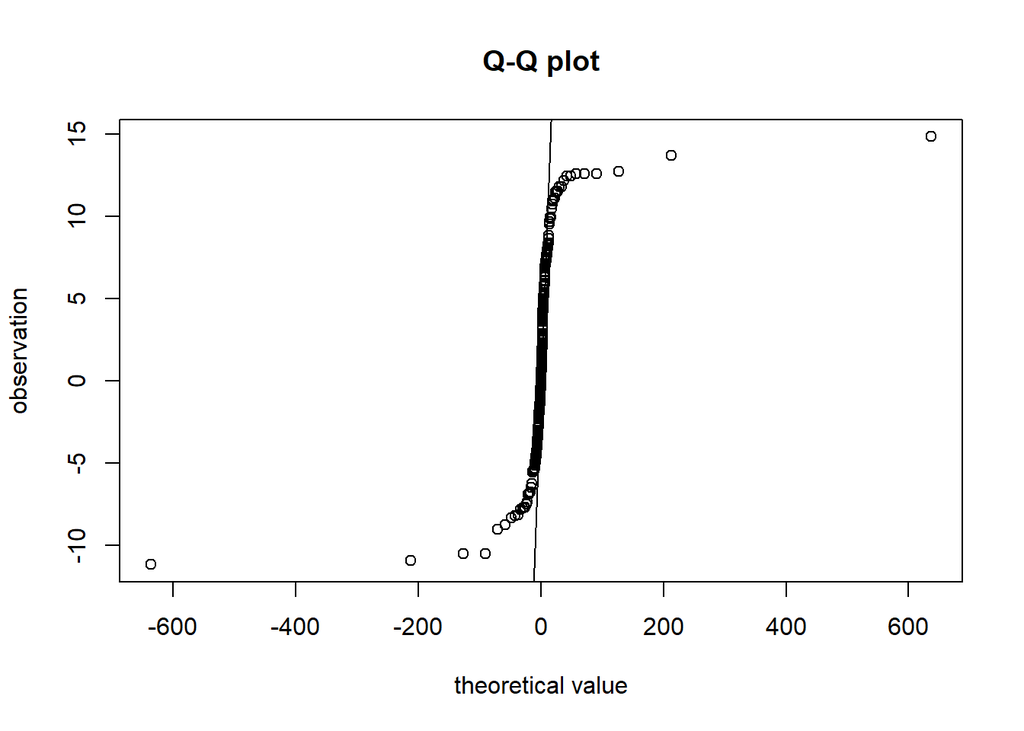

```r
rw <- rw0$x[1001:2000]

#Q-Qplot
qqplot(qt(ppoints(1000), df = 1), rw,main="Q-Q plot",xlab="theoretical value",ylab="observation")
abline(c(0,0),c(1,1))
```

```r
#Observed deciles
print(sort(rw)[100*1:9])
```

```
## [1] -2.02829505 -1.14341580 -0.57977137 -0.26089784  0.08873769  0.27450783
## [7]  0.65310903  1.24512865  3.99239134
```

```r
#Theoretical deciles
qt(1:9/10, df = 1)
```

```
## [1] -3.0776835 -1.3763819 -0.7265425 -0.3249197  0.0000000  0.3249197
## [7]  0.7265425  1.3763819  3.0776835
```

Q-Q plot is not straight because Cauchy distribution is a heavy tail distribution, and the normal distribution as the proposed distribution produces more random numbers.so Q-Q plot is not a straight line.

## Question

Exercises 9.6 (Page 277,Statistical Computing with R )

Rao [220, Sec. 5g] presented an example on genetic linkage of 197 animals in four categories (also discussed in [67, 106, 171, 266]). The group sizes are (125, 18, 20, 34). Assume that the probabilities of the corresponding multinomial distribution are
$$(\frac{1}{2}+\frac{\theta}{4},\frac{1-\theta}{4},\frac{1-\theta}{4},\frac{\theta}{4})$$
Estimate the posterior distribution of θ given the observed sample, using one of the methods in this chapter.

## Answer

```r
set.seed(123)
m <- 5000 #length of the chain
w <- .5 #width of the uniform support set
burn <- 1000 #burn-in time
x <- numeric(m)#the chain
x0 <- c(125,18,20,34)#the observed sample
d <- sum(x0)
prob <- function(y, x) {      ### computes the target density
  if (y < 0 || y >= 1)
    return (0)
  return((0.5+y/4)^x[1]*(0.25-y/4)^(x[2]+x[3])*(y/4)^x[4])
}

u <- runif(m)         #for accept/reject step
v <- runif(m, -w, w)  #proposal distribution
x[1] <- .1
for (i in 2:m) {
  y <- x[i-1] + v[i]
  if (u[i] < prob(y, x0) / prob(x[i-1], x0))
    x[i] <- y  else
      x[i] <- x[i-1]
}
print(round(x0/d, 3))
```

```
## [1] 0.635 0.091 0.102 0.173
```

```r
xb <- x[(burn+1):m]
print(mean(xb))
```

```
## [1] 0.6244389
```

```r
print(sd(xb))
```

```
## [1] 0.05270262
```

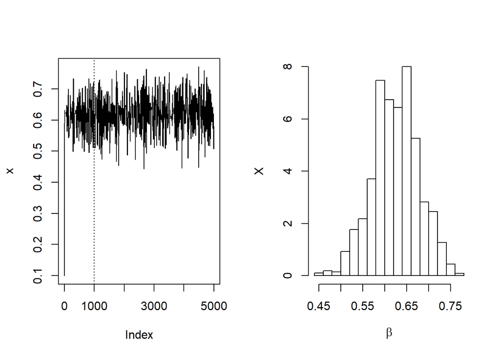

```r
# plot to check convergence
par(mfrow=c(1,2))
plot(x, type="l")
abline( v=burn+1, lty=3)
hist(xb, freq=F, xlab=bquote(beta), ylab="X", main="")
```

## Question

Exercises 9.6 (Page 277,Statistical Computing with R )

Rao [220, Sec. 5g] presented an example on genetic linkage of 197 animals in four categories (also discussed in [67, 106, 171, 266]). The group sizes are (125, 18, 20, 34). Assume that the probabilities of the corresponding multinomial distribution are
$$(\frac{1}{2}+\frac{\theta}{4},\frac{1-\theta}{4},\frac{1-\theta}{4},\frac{\theta}{4})$$
Estimate the posterior distribution of $\theta$ given the observed sample, using one of the methods in this chapter.

For exercise 9.6, use the Gelman-Rubin method to monitor convergence of the chain, and run the chain until the chain has converged approximately to the target distribution according to $\hat{R}<1.2$.

## Answer

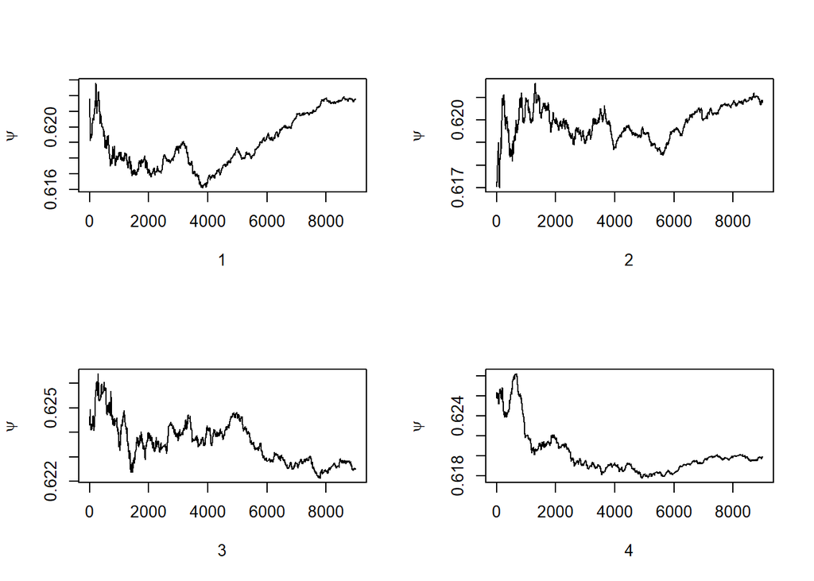

```r
Gelman.Rubin <- function(psi) {
psi<-as.matrix(psi)        # psi[i,j] is the statistic psi(X[i,1:j])
n<-ncol(psi)               # for chain in i-th row of X
k<-nrow(psi)
psi.means<-rowMeans(psi)   #row means
B<-n*var(psi.means)        #between variance est.
psi.w<-apply(psi,1,"var")  #within variances
W<-mean(psi.w)             #within est.
v.hat<-W*(n-1)/n+(B/n)     #upper variance est.
r.hat<-v.hat/W             #G-R statistic
return(r.hat)
}

mult.chain<-function(ob,w,m,x1){
x<-numeric(m)      #the chain
u<-runif(m)        #for accept/reject step
v<-runif(m,-w,w)   #proposal distribution
x[1]<-x1
for(i in 2:m) {
y<-x[i-1]+v[i]
if(u[i]<=prob(y,ob)/prob(x[i-1],ob)){
x[i]<-y
}else{
x[i]<-x[i-1]}
}
return(x)
}

prob <- function(y, x) {      ### computes the target density
  if (y < 0 || y >= 1)
    return (0)
  return((0.5+y/4)^x[1]*(0.25-y/4)^(x[2]+x[3])*(y/4)^x[4])
}


w<-.5               #width of the uniform support set
burn<-1000          #burn-in time
ob<-c(125,18,20,34) #the observed sample
m<-10000            #length of the chain
k<-4                #number of chains to generate
x0<-c(0.5,0.9,0.1,0.75)  #choose overdispersed initial values

set.seed(123)     #generate the chains
X<-matrix(0,nrow=k,ncol=m)
for(i in 1:k){
X[i, ]<-mult.chain(ob,w,m,x0[i])
}

psi<-t(apply(X,1,cumsum)) #compute diagnostic statistics
for(i in 1:nrow(psi)){
psi[i,]<-psi[i,]/(1:ncol(psi))
}

par(mfrow=c(2,2))  #plot psi for the four chains
for(i in 1:k)
plot(psi[i,(burn+1):m],type="l",xlab=i,ylab=bquote(psi))
```

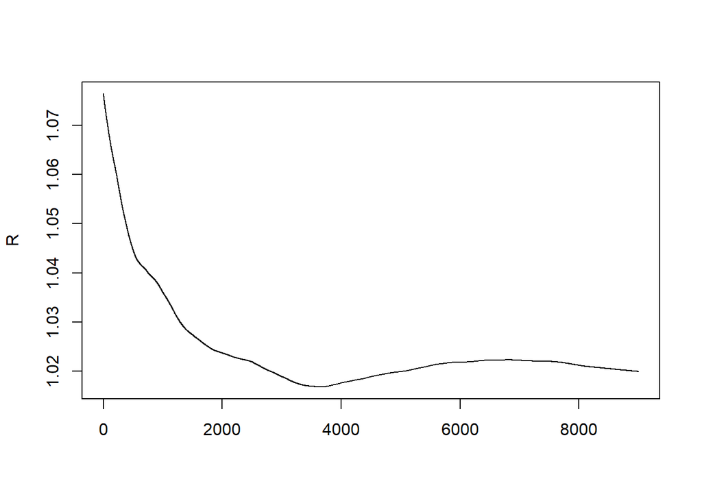

```r
par(mfrow=c(1,1)) #restore default

#plot the sequence of R-hat statistics
rhat<-rep(0,m)
for(j in (burn+1):m)
rhat[j]<-Gelman.Rubin(psi[,1:j])
plot(rhat[(burn+1):m],type="l",xlab="",ylab="R")
abline(h=1.2,lty=2)
```

## Question

Exercises 11.4 (Page 353,Statistical Computing with R )

Find the intersection points A(k) in $(0, \sqrt{k})$ of the curves
$$S_{k-1}(a)=P(t(k-1)>\sqrt{\frac{a^2(k-1)}{k-a^2}})$$
$$S_{k}(a)=P(t(k)>\sqrt{\frac{a^2k}{k+1-a^2}})$$
for k = 4 : 25, 100, 500, 1000, where t(k) is a Student t random variable with k degrees of freedom. (These intersection points determine the critical values for a t-test for scale-mixture errors proposed by Szekely [260].)

## Answer

```r
ds<-function(a){
sk1<-1-pt(sqrt(a^2*(k-1)/(k-a^2)),df=k-1)
sk2<-1-pt(sqrt(a^2*k/(k+1-a^2)),df=k)
return(sk1-sk2)
}                 ##s_k-s_{k-1}
absds<-function(a){abs(ds(a))}

solution<-function(x){
assign("k",x,pos=1)
if(k<=22){
myfit<-uniroot(ds,c(1e-4,sqrt(x)-1e-4))$root
}else{
myfit<-optimize(absds,c(0,3))$minimum        ##while k>22,upper=3
}
return(myfit)
}
A.k<-sapply(c(4:25,100,500,1000),solution)
result<-data.frame(k=c(4:25,100,500,1000),ponits=A.k)
t(result)
```

```
##            [,1]     [,2]     [,3]     [,4]     [,5]     [,6]      [,7]
## k      4.000000 5.000000 6.000000 7.000000 8.000000 9.000000 10.000000
## ponits 1.492103 1.533549 1.562768 1.584421 1.601192 1.614517  1.625391
##             [,8]      [,9]     [,10]     [,11]     [,12]     [,13]
## k      11.000000 12.000000 13.000000 14.000000 15.000000 16.000000
## ponits  1.634409  1.642004  1.648565  1.654167  1.659099  1.663452
##            [,14]     [,15]    [,16]     [,17]     [,18]     [,19]
## k      17.000000 18.000000 19.00000 20.000000 21.000000 22.000000
## ponits  1.667288  1.670736  1.67384  1.676588  1.679139  1.681461
##            [,20]     [,21]     [,22]      [,23]      [,24]       [,25]
## k      23.000000 24.000000 25.000000 100.000000 500.000000 1000.000000
## ponits  1.683601  1.685543  1.687352   1.720596   1.729762    1.730893
```

## Question

Exercises 9.6 (Page 354,Statistical Computing with R )

Write a function to compute the cdf of the Cauchy distribution, which has density
$$\frac{1}{\theta \pi (1+[(x-\mu)/\theta]^2)},-\infty<x<\infty$$
where ?? > 0. Compare your results to the results from the R function pcauchy. (Also see the source code in pcauchy.c.)

## Answer

```r
pdfcauchy<-function(x,theta,mu){    ###pdf of Cauchy distribution
1/(theta*pi*(1+((x-mu)/theta)^2))
}
cdfcauchy<-function(x,theta,mu){     ###cdf of Cauchy distribution
res<-integrate(pdfcauchy,lower=-Inf,upper=x,rel.tol=.Machine$double.eps^0.25,theta=theta,mu=mu)
res$value
}
upper<-seq(-10,10,2)
result<-rbind(x=as.integer(upper),cdfcauchy=mapply(cdfcauchy,upper,1,0),pcauchy=pcauchy(upper)) #default theta=1, mu=0
options(warn=-1)
knitr::kable(result, format = "markdown")
```

| x | -10.0000000 | -8.0000000 | -6.0000000 | -4.0000000 | -2.0000000 | 0.0 | 2.0000000 | 4.0000000 | 6.0000000 | 8.0000000 | 10.0000000 |
| --- | --- | --- | --- | --- | --- | --- | --- | --- | --- | --- | --- |
| cdfcauchy | 0.0317255 | 0.0395834 | 0.0525685 | 0.0779791 | 0.1475836 | 0.5 | 0.8524164 | 0.9220209 | 0.9474315 | 0.9604166 | 0.9682745 |
| pcauchy | 0.0317255 | 0.0395834 | 0.0525685 | 0.0779791 | 0.1475836 | 0.5 | 0.8524164 | 0.9220209 | 0.9474315 | 0.9604166 | 0.9682745 |

## Question

- Homework-11.30
  - A-B-O blood type problem
    - Let the three alleles be A, B, and O.

    | Genotype | AA | BB | OO | AO | BO | AB | AA |
    | --- | --- | --- | --- | --- | --- | --- | --- |
    | Frequency | p^2 | q^2 | r^2 | 2pr | 2qr | 2pq | 1 |
    | Count | nAA | nBB | nOO | nAO | nBO | nAB | n |

    - Observed data: $n_{A\cdot}=n_{AA}+n_{AO}=28$ (A-type), $n_{B\cdot}=n_{BB}+n_{BO}=24$ (B-type), $n_{OO}=41$ (O-type), $n_{AB}=70$ (AB-type).
    - Use EM algorithm to solve MLE of $p$ and $q$ (consider missing data $n_{AA}$ and $n_{BB}$).
    - Record the maximum likelihood values in M-steps, are they increasing?

## Answer

```r
set.seed(123)
nA<-28
nB<-24
nO<-41
nAB<-70

N<-10000 #max. number of  iterations
L.old<-c(.2,.35)  #initial est. for p and q
tol<-.Machine$double.eps
M.value<-0
L.list<-data.frame(p=0,q=0)

mlogL<-function(l,l.old){
r<-1-sum(l)
r.old<-1-sum(l.old)
nAA<-round(nA*l.old[1]^2/(l.old[1]^2+2*l.old[1]*r.old))
nBB<-round(nB*l.old[2]^2/(l.old[2]^2+2*l.old[2]*r.old))
llh<-2*nO*log(r)+nAB*log(2*l[1]*l[2])+2*nAA*log(l[1])+2*nBB*log(l[2])+(nA-nAA)*log(2*l[1]*r)+(nB-nBB)*log(2*l[2]*r)
-llh
}

for(j in 1:N){
res<-optim(c(0.3,0.2),mlogL,l.old=L.old)
L<-res$par
L.list[j,]<-L
M.value[j]<- -res$value
if(sum(abs(L-L.old)/L.old)<tol) break
L.old<-L
}
L.list  #p,q
```

```
##           p         q
## 1 0.3159679 0.3098472
## 2 0.3251760 0.3097911
## 3 0.3281913 0.3098116
## 4 0.3281913 0.3098116
```

```r
M.value  ##the max likelihood values
```

```
## [1] -280.6875 -283.1944 -283.9943 -283.9943
```

## Question

Exercise 3 (Page 204,Advanced R )

Use both for loops and lapply() to fit linear models to the mtcars using the formulas stored in this list:

formulas <- list( mpg ~ disp, mpg ~ I(1 / disp), mpg ~ disp + wt, mpg ~ I(1 / disp) + wt )

## Answer

```r
formulas <- list(
mpg ~ disp,
mpg ~ I(1 / disp),
mpg ~ disp + wt,
mpg ~ I(1 / disp) + wt
)
boot_lm <- function(i) {
lm(formulas[[i]], data = mtcars)
}
lapply(1:4, boot_lm)  ###lapply()
```

```
## [[1]]
##
## Call:
## lm(formula = formulas[[i]], data = mtcars)
##
## Coefficients:
## (Intercept)         disp
##    29.59985     -0.04122
##
##
## [[2]]
##
## Call:
## lm(formula = formulas[[i]], data = mtcars)
##
## Coefficients:
## (Intercept)    I(1/disp)
##       10.75      1557.67
##
##
## [[3]]
##
## Call:
## lm(formula = formulas[[i]], data = mtcars)
##
## Coefficients:
## (Intercept)         disp           wt
##    34.96055     -0.01772     -3.35083
##
##
## [[4]]
##
## Call:
## lm(formula = formulas[[i]], data = mtcars)
##
## Coefficients:
## (Intercept)    I(1/disp)           wt
##      19.024     1142.560       -1.798
```

```r
x<-vector("list", length(formulas))
for(i in 1:4)x[[i]]<-lm(formulas[[i]],data=mtcars)
x  ###for loops
```

```
## [[1]]
##
## Call:
## lm(formula = formulas[[i]], data = mtcars)
##
## Coefficients:
## (Intercept)         disp
##    29.59985     -0.04122
##
##
## [[2]]
##
## Call:
## lm(formula = formulas[[i]], data = mtcars)
##
## Coefficients:
## (Intercept)    I(1/disp)
##       10.75      1557.67
##
##
## [[3]]
##
## Call:
## lm(formula = formulas[[i]], data = mtcars)
##
## Coefficients:
## (Intercept)         disp           wt
##    34.96055     -0.01772     -3.35083
##
##
## [[4]]
##
## Call:
## lm(formula = formulas[[i]], data = mtcars)
##
## Coefficients:
## (Intercept)    I(1/disp)           wt
##      19.024     1142.560       -1.798
```

## Question

Exercise 4 (Page 204,Advanced R )

Fit the model mpg ~ disp to each of the bootstrap replicates of mtcars in the list below by using a for loop and lapply(). Can you do it without an anonymous function? bootstraps <- lapply(1:10, function(i) { rows <- sample(1:nrow(mtcars), rep = TRUE) mtcars[rows, ] }) ##Answer

```r
set.seed(123)
bootstraps<-lapply(1:10,function(i){
rows<-sample(1:nrow(mtcars),rep = TRUE)
mtcars[rows, ]
})
x<-vector("list",10)
for(i in 1:10){
x[[i]]<-lm(mpg~disp,data=bootstraps[[i]])
}
x   ###for loops
```

```
## [[1]]
##
## Call:
## lm(formula = mpg ~ disp, data = bootstraps[[i]])
##
## Coefficients:
## (Intercept)         disp
##     30.0287      -0.0434
##
##
## [[2]]
##
## Call:
## lm(formula = mpg ~ disp, data = bootstraps[[i]])
##
## Coefficients:
## (Intercept)         disp
##    29.44060     -0.03799
##
##
## [[3]]
##
## Call:
## lm(formula = mpg ~ disp, data = bootstraps[[i]])
##
## Coefficients:
## (Intercept)         disp
##    28.92155     -0.03918
##
##
## [[4]]
##
## Call:
## lm(formula = mpg ~ disp, data = bootstraps[[i]])
##
## Coefficients:
## (Intercept)         disp
##    29.10046     -0.04044
##
##
```

[output cut: 43 more lines]

```
## lm(formula = mpg ~ disp, data = bootstraps[[i]])
##
## Coefficients:
## (Intercept)         disp
##    27.47647     -0.03299
##
##
## [[10]]
##
## Call:
## lm(formula = mpg ~ disp, data = bootstraps[[i]])
##
## Coefficients:
## (Intercept)         disp
##    28.61819     -0.03719
```

```r
lapply(bootstraps,lm,formula=mpg~disp)  ###lapply()
```

```
## [[1]]
##
## Call:
## FUN(formula = ..1, data = X[[i]])
##
## Coefficients:
## (Intercept)         disp
##     30.0287      -0.0434
##
##
## [[2]]
##
## Call:
## FUN(formula = ..1, data = X[[i]])
##
## Coefficients:
## (Intercept)         disp
##    29.44060     -0.03799
##
##
## [[3]]
##
## Call:
## FUN(formula = ..1, data = X[[i]])
##
## Coefficients:
## (Intercept)         disp
##    28.92155     -0.03918
##
##
## [[4]]
##
## Call:
## FUN(formula = ..1, data = X[[i]])
##
## Coefficients:
## (Intercept)         disp
##    29.10046     -0.04044
##
##
```

[output cut: 43 more lines]

```
## FUN(formula = ..1, data = X[[i]])
##
## Coefficients:
## (Intercept)         disp
##    27.47647     -0.03299
##
##
## [[10]]
##
## Call:
## FUN(formula = ..1, data = X[[i]])
##
## Coefficients:
## (Intercept)         disp
##    28.61819     -0.03719
```

## Question

Exercise 5 (Page 204,Advanced R )

For each model in the previous two exercises, extract R2 using the function below. rsq <- function(mod) summary(mod)$r.squared ##Answer

```r
rsq <- function(mod) summary(mod)$r.squared
lapply(lapply(1:4,boot_lm),rsq)                      #exercise 3
```

```
## [[1]]
## [1] 0.7183433
##
## [[2]]
## [1] 0.8596865
##
## [[3]]
## [1] 0.7809306
##
## [[4]]
## [1] 0.8838038
```

```r
lapply(lapply(bootstraps,lm,formula=mpg ~ disp),rsq)   #exercise 4
```

```
## [[1]]
## [1] 0.7475099
##
## [[2]]
## [1] 0.7179526
##
## [[3]]
## [1] 0.7571433
##
## [[4]]
## [1] 0.6921848
##
## [[5]]
## [1] 0.8488426
##
## [[6]]
## [1] 0.7702828
##
## [[7]]
## [1] 0.7491175
##
## [[8]]
## [1] 0.7843995
##
## [[9]]
## [1] 0.677981
##
## [[10]]
## [1] 0.7887093
```

## Question

Exercises 3 (Page 214,Advanced R ) The following code simulates the performance of a t-test for non-normal data. Use sapply() and an anonymous function to extract the p-value from every trial. trials <- replicate( 100, t.test(rpois(10, 10), rpois(7, 10)), simplify = FALSE ) Extra challenge: get rid of the anonymous function by using [[ directly.

## Answer

```r
trials = replicate(100,t.test(rpois(10, 10), rpois(7, 10)),simplify = FALSE)
sapply(seq_along(trials), function(i){trials[[i]]$p.value})           #get rid of the anonymous function by using [[ directly
```

```
##   [1] 0.807919932 0.665511753 0.827771652 0.534899644 0.211737338
##   [6] 0.528643574 0.036299941 0.016286246 0.812200341 0.183029433
##  [11] 0.045674206 0.420195198 0.577173408 0.874254166 0.677908319
##  [16] 0.347553226 0.361554497 0.918737314 0.559098294 0.002509499
##  [21] 0.768217661 0.898061689 0.003256698 1.000000000 0.160902588
##  [26] 0.968015378 0.945869071 0.487230574 0.790842602 0.312865917
##  [31] 0.526127245 0.960313898 0.408238277 0.535864285 0.129220433
##  [36] 0.521667733 0.952101571 0.929053803 0.971746957 0.011601477
##  [41] 0.374260383 0.692475913 0.153917384 0.645121214 0.181853971
##  [46] 0.224322502 0.163462092 1.000000000 0.826032130 0.679110040
##  [51] 0.371457538 0.839837144 0.503046077 0.201307366 0.383173622
##  [56] 0.528297119 0.146797813 0.148537031 0.069654366 0.165229047
##  [61] 0.295638950 0.895620390 0.219622769 0.843794785 0.313497276
##  [66] 0.815388972 0.232485704 0.992897313 0.894949409 0.737031460
##  [71] 0.033341396 0.915558739 0.605572394 0.295777799 0.838840978
##  [76] 0.574006877 0.156308726 0.912461904 0.312905736 0.673237060
##  [81] 0.868453722 0.165275770 0.776816328 0.170876446 0.888611596
##  [86] 0.345857314 0.804162036 0.587077292 0.419642761 0.018360012
##  [91] 0.771416249 0.745960582 0.239627472 0.824506887 0.990644333
##  [96] 0.290741422 0.594800048 0.272107922 0.981034416 0.947306215
```

```r
# without anonymous function
sapply(trials,"[[",3)
```

```
##   [1] 0.807919932 0.665511753 0.827771652 0.534899644 0.211737338
##   [6] 0.528643574 0.036299941 0.016286246 0.812200341 0.183029433
##  [11] 0.045674206 0.420195198 0.577173408 0.874254166 0.677908319
##  [16] 0.347553226 0.361554497 0.918737314 0.559098294 0.002509499
##  [21] 0.768217661 0.898061689 0.003256698 1.000000000 0.160902588
##  [26] 0.968015378 0.945869071 0.487230574 0.790842602 0.312865917
##  [31] 0.526127245 0.960313898 0.408238277 0.535864285 0.129220433
##  [36] 0.521667733 0.952101571 0.929053803 0.971746957 0.011601477
##  [41] 0.374260383 0.692475913 0.153917384 0.645121214 0.181853971
##  [46] 0.224322502 0.163462092 1.000000000 0.826032130 0.679110040
##  [51] 0.371457538 0.839837144 0.503046077 0.201307366 0.383173622
##  [56] 0.528297119 0.146797813 0.148537031 0.069654366 0.165229047
##  [61] 0.295638950 0.895620390 0.219622769 0.843794785 0.313497276
##  [66] 0.815388972 0.232485704 0.992897313 0.894949409 0.737031460
##  [71] 0.033341396 0.915558739 0.605572394 0.295777799 0.838840978
##  [76] 0.574006877 0.156308726 0.912461904 0.312905736 0.673237060
##  [81] 0.868453722 0.165275770 0.776816328 0.170876446 0.888611596
##  [86] 0.345857314 0.804162036 0.587077292 0.419642761 0.018360012
##  [91] 0.771416249 0.745960582 0.239627472 0.824506887 0.990644333
##  [96] 0.290741422 0.594800048 0.272107922 0.981034416 0.947306215
```

## Question

Exercises 6 (Page 214,Advanced R ) Implement a combination of Map() and vapply() to create an lapply() variant that iterates in parallel over all of its inputs and stores its outputs in a vector (or a matrix). What arguments should the function take?

## Answer

```r
lapply2<-function (f,n,type="numeric",...){             #lapply()
  ##f=function,n=ncol
f<-match.fun(f)
if(type=="numeric")  y=vapply(Map(f, ...),cbind,numeric(n))
else if(type=="character") y=vapply(Map(f, ...),cbind,character(n))
else if(type=="complex") y=vapply(Map(f, ...),cbind,complex(n))
else if(type=="logical") y=vapply(Map(f, ...),cbind,logical(n))
return(y)
}
```

Then we use question 4 to test lapply2().

```r
set.seed(123)
trials <- replicate(
100,
t.test(rpois(10, 10), rpois(7, 10)),
simplify = FALSE
)
p<-function(x){
x$p.value
}
lapply2(p,1,"numeric",trials)
```

```
##   [1] 9.813226e-01 1.619096e-05 6.242135e-01 6.693526e-01 5.677105e-01
##   [6] 6.610740e-01 5.951636e-01 5.005347e-01 4.763110e-01 3.429965e-01
##  [11] 8.155394e-01 7.197238e-01 1.244336e-01 2.229164e-01 1.113099e-02
##  [16] 4.625765e-01 6.515865e-01 1.658793e-01 9.342672e-01 8.011934e-01
##  [21] 4.627657e-01 5.927934e-01 2.929669e-01 5.737967e-01 3.451537e-02
##  [26] 2.739138e-01 2.656151e-01 8.196695e-01 6.647355e-01 8.056529e-01
##  [31] 5.060850e-01 7.106543e-01 2.321066e-01 1.106223e-01 5.459279e-01
##  [36] 1.865470e-02 2.433776e-01 2.688851e-01 9.819256e-01 4.940184e-01
##  [41] 3.268275e-01 8.000439e-01 9.822499e-01 1.936454e-01 7.390101e-01
##  [46] 3.888930e-02 4.350424e-01 7.434339e-02 5.787441e-01 4.864951e-01
##  [51] 1.476288e-01 5.524909e-01 7.129280e-01 8.683479e-03 9.053256e-02
##  [56] 4.415463e-01 4.955063e-01 1.745328e-01 6.615399e-01 4.479199e-01
##  [61] 2.885849e-01 3.028567e-02 1.018907e-01 1.811861e-02 6.376441e-01
##  [66] 1.408742e-02 9.008128e-02 4.515933e-01 8.703291e-01 7.250768e-01
##  [71] 8.183571e-01 8.465036e-01 8.786838e-01 1.651543e-01 3.951569e-01
##  [76] 1.754280e-01 3.649865e-01 7.224226e-02 6.565152e-01 9.946559e-01
##  [81] 3.715952e-01 8.424336e-02 4.549887e-01 8.530113e-01 1.970777e-01
##  [86] 2.298117e-01 1.148832e-01 7.769502e-01 4.934348e-01 3.526049e-01
##  [91] 2.036013e-01 8.838914e-01 6.474880e-02 4.089082e-01 5.780132e-01
##  [96] 8.011408e-01 5.956061e-01 9.266689e-01 9.923205e-02 1.763972e-01
```

## Question

Exercise 4 (Page 365,Advanced R )

Make a faster version of chisq.test() that only computes the chi-square test statistic when the input is two numeric vectors with no missing values. You can try simplifying chisq.test() or by coding from the mathematical definition (http://en. wikipedia.org/wiki/Pearson%27s_chi-squared_test)

## Answer

```r
library(microbenchmark)
chisq.test2<-function(x,y){
  input<-as.table(rbind(x,y))
  out<-chisq.test(input)$statistic
  out
}

mya<-c(576,123,746);myb<-c(246,588,376)    #example
chisq.test2(mya,myb)
```

```
## X-squared
##  542.0563
```

```r
chisq.test(rbind(mya,myb))
```

```
##
##  Pearson's Chi-squared test
##
## data:  rbind(mya, myb)
## X-squared = 542.06, df = 2, p-value < 2.2e-16
```

```r
microbenchmark(t1=chisq.test2(mya,myb),t2=chisq.test(rbind(mya,myb)))
```

```
## Unit: microseconds
##  expr     min       lq      mean  median       uq      max neval
##    t1 147.943 154.8995 186.73214 157.913 161.3920 2864.694   100
##    t2  70.957  77.4500  83.33054  83.015  85.1025  148.870   100
```

## Question

Exercise 5 (Page 365,Advanced R )

Can you make a faster version of table() for the case of an input of two integer vectors with no missing values? Can you use it to speed up your chi-square test?

## Answer

```r
table2<-function(...,dnn = list.names(...),deparse.level = 1){
    list.names <- function(...) {
        l <- as.list(substitute(list(...)))[-1L]
        nm <- names(l)
        fixup <- if (is.null(nm))
            seq_along(l)
        else nm == ""
        dep <- vapply(l[fixup], function(x) switch(deparse.level +
            1, "", if (is.symbol(x)) as.character(x) else "",
            deparse(x, nlines = 1)[1L]), "")
        if (is.null(nm))
            dep
        else {
            nm[fixup] <- dep
            nm
        }
    }
    args <- list(...)
    if (!length(args))
        stop("nothing to tabulate")
    if (length(args) == 1L && is.list(args[[1L]])) {
        args <- args[[1L]]
        if (length(dnn) != length(args))
            dnn <- if (!is.null(argn <- names(args)))
                argn
            else paste(dnn[1L], seq_along(args), sep = ".")
    }
    bin <- 0L
    lens <- NULL
    dims <- integer()
    pd <- 1L
    dn <- NULL
    for (a in args) {
        if (is.null(lens))
            lens <- length(a)
        else if (length(a) != lens)
            stop("all arguments must have the same length")
        fact.a <- is.factor(a)
        if (!fact.a) {
            a0 <- a
            a <- factor(a)
        }
        ll <- levels(a)
        a <- as.integer(a)
        nl <- length(ll)
        dims <- c(dims, nl)
        dn <- c(dn, list(ll))
        bin <- bin + pd * (a - 1L)
        pd <- pd * nl
    }
    names(dn) <- dnn
    bin <- bin[!is.na(bin)]
    if (length(bin))
        bin <- bin + 1L
    y <- array(tabulate(bin, pd), dims, dimnames = dn)
    class(y) <- "table"
    y
}

mya<-myb<-c(1,seq(1,4))            #example
table2(mya,myb)
```

```
##    myb
## mya 1 2 3 4
##   1 2 0 0 0
##   2 0 1 0 0
##   3 0 0 1 0
##   4 0 0 0 1
```

```r
table(mya,myb)
```

```
##    myb
## mya 1 2 3 4
##   1 2 0 0 0
##   2 0 1 0 0
##   3 0 0 1 0
##   4 0 0 0 1
```

```r
microbenchmark(t1=table2(mya,myb),t2=table(mya,myb))
```

```
## Unit: microseconds
##  expr     min       lq     mean   median      uq     max neval
##    t1 123.826 127.0735 137.8325 131.9425 139.827 233.276   100
##    t2 132.175 135.8850 146.0691 141.4500 148.406 309.334   100
```